# EDA USDJPY

Garrett Shankel

2022-07-08

The Foreign Exchange market lends itself nicely to time series analysis. A number of common trends are seen in the day to day behavior of currency pairs. For example the USD/JPY pair has a periods of time where volume drops and trading slows just before a big move is made. One notable time when this happens is between days. Since forex is a 24 hour market news events that happened on one side of the world can be reflected 12 hours later when a new market opens. In this analysis we will focus on using a weeks worth of data to predict the next days trend.

First we start with reading in the data. Typically after this step we would spend a long time cleaning the data, but thanks to the forex markets strong bookkeeping all we need to do is convert our time units into decimals to make the data easier to work with.

This data set encompasses 10 years worth of data. For back testing having this amount of data will be useful, but for now we will look at the most recent week in order to build our initial model. In the following plot we show 7 days worth of data. Marked by the red line is a common point of low trading volume. At this marker it will be 3:00 AM in Tokyo, 2:00 PM in New York, and 7:00 PM in London. Two of the major markets in the world are asleep and one of the major markets is getting ready to close. This would serve as a good entry point to take a trade in the hopes of predicting the next days trend.

We can see between points 5 and 10 on the x-axis that some notable trends emerge. This is when the tokyo market opens and gets into full swing. Our goal would be to determine this trend the previous day.

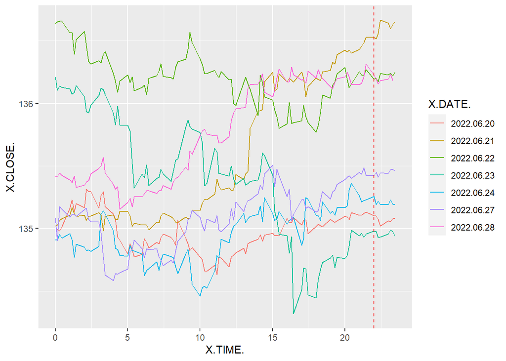

```r
library(ggplot2)
usdJpyRecentWeek <- usdJpy[247018:247688,]

ggplot(usdJpyRecentWeek[1:670,], aes(x = X.TIME., y = X.CLOSE., group = X.DATE., color = X.DATE.)) + geom_line() + geom_vline(xintercept = 22, linetype = "dashed", color = "red")
```

In order to perform a time series analysis though our data must be stationary. A quick glance at the previous plot shows that one of the major pillars of stationary data is broken, constant mean. The mean moves along the trend of trading and not in a straight constant line. Visually we can also see that there is not constant variance in these plots. The market varies wildly throughout the day and does not appear to vary around a centered line. Visually this is pretty clear, but lets confirm these assumptions with a Dickey-Fuller test. The hypothesis test for the Dickey-Fuller test is that the data is non-stationary. Therefore if our p-value is greater than 0.05 we can conclude that the data is likely non-stationary. Before performing the test we will convert our data into a time series object with a frequency of 95. 95 observations to make 1 day. Or 1440 minutes / 15 minutes - the final observation. We omit the final observation becuase the time goes from 23:45 to 0:00 not 23:45 to 24:00.

```
##
##  Augmented Dickey-Fuller Test
##
## data:  tsClose
## Dickey-Fuller = -1.6813, Lag order = 8, p-value = 0.7132
## alternative hypothesis: stationary
```

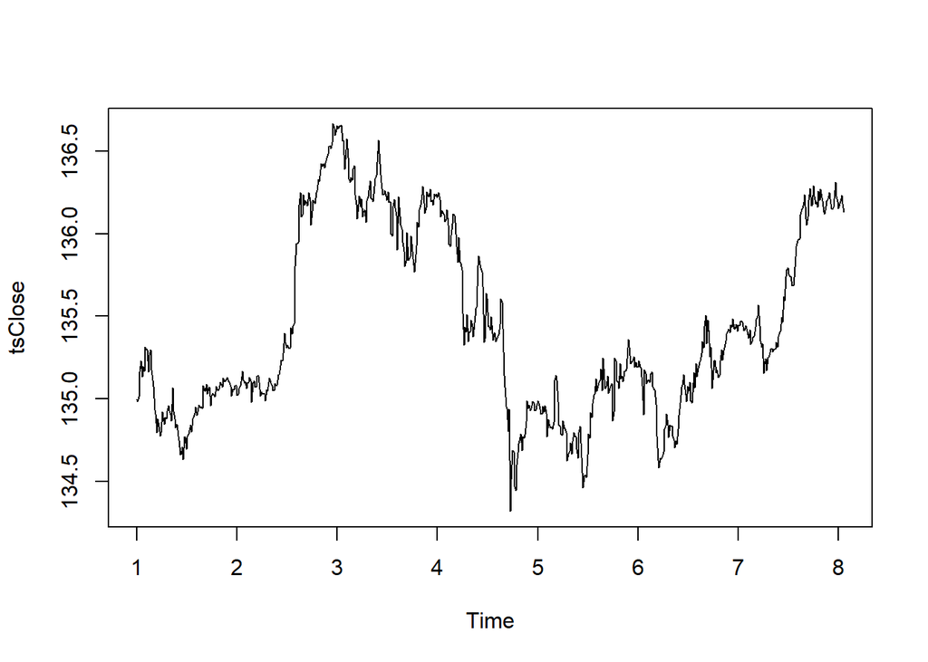

As expected our p-value is much larger than 0.05. Meaning that it is likely that the data is non-stationary. We will need to adjust it so that we can fit a time series model.

Since our data is non-stationary lets first look at how a Holt Winters forecasting method works. This method works with both non-stationary and stationary time series. We’ll use a 95% confidence interval and attempt to predict ahead by 24 observations (6 hours)

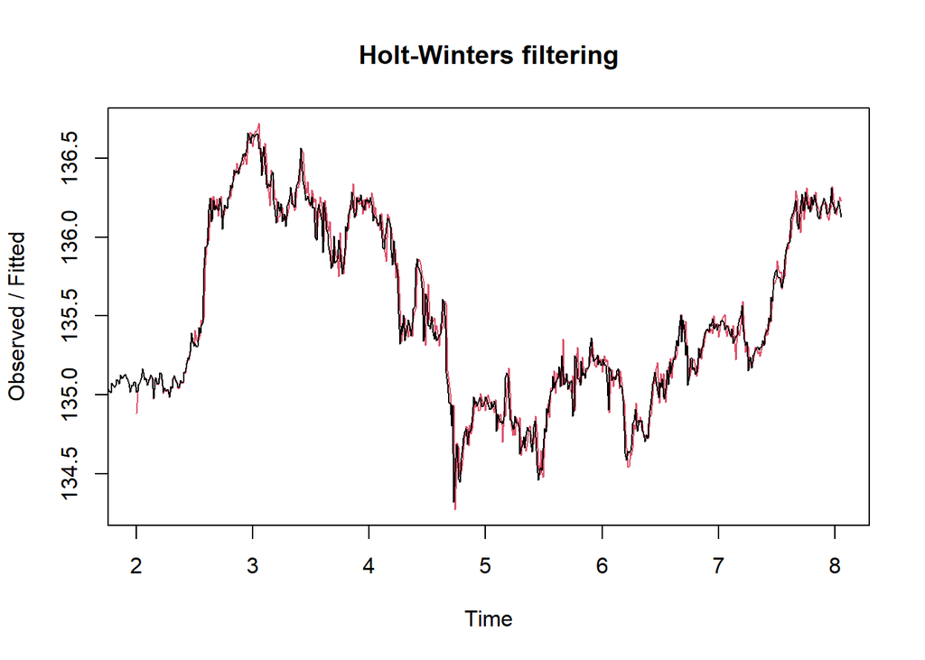

```r
library(stats)
hw.fit <- HoltWinters(tsClose)

plot(hw.fit)
```

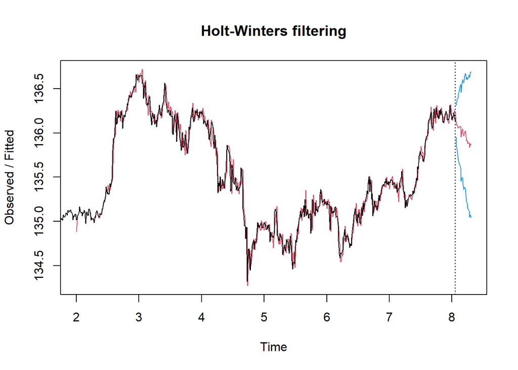

```r
forecast.hw <- predict(hw.fit, n.ahead = 24, prediction.interval = T, level = 0.95)
plot(hw.fit, forecast.hw)
```

Holt Winters predicts a strong down trend for the USD JPY the next day. For reference the next day in this case is the 29th of June 2022 and the trend for that day was moderately upward. So far Holt Winters has not performed well. We will return to this but first lets see how well things work if we make the data stationary.

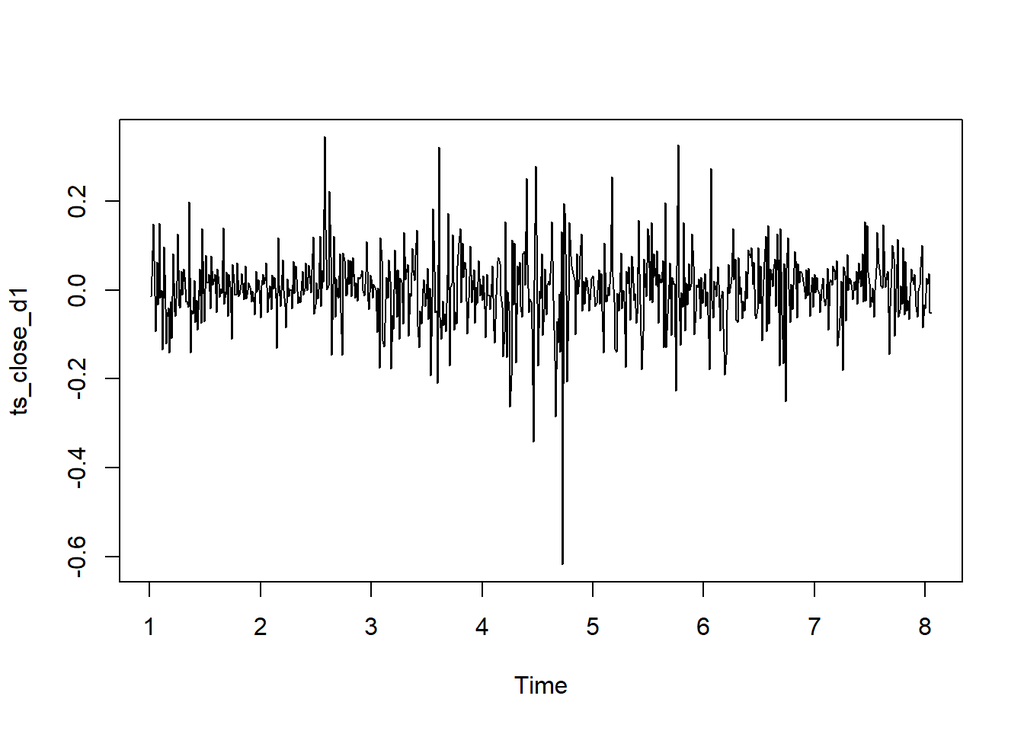

```r
ts_close_d1 <- diff(tsClose, differences = 1)
plot(ts_close_d1)
```

```r
adf.test(ts_close_d1)
```

```
##
##  Augmented Dickey-Fuller Test
##
## data:  ts_close_d1
## Dickey-Fuller = -8.8571, Lag order = 8, p-value = 0.01
## alternative hypothesis: stationary
```

Based on the test it looks like our time series model now meets the requirements for stationarity. The plot also shows behavior more like “noise” which is what we would like to see in our time series. Now that we have met the stationary requirement we can build our model. We will use Holt Winters forecasting again with a 95% confidence interval. We will predict 24 observations into the future.

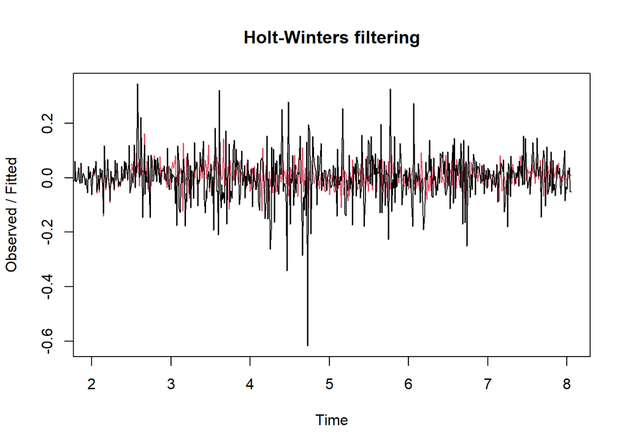

```r
hw.fit <- HoltWinters(ts_close_d1)

plot(hw.fit)
```

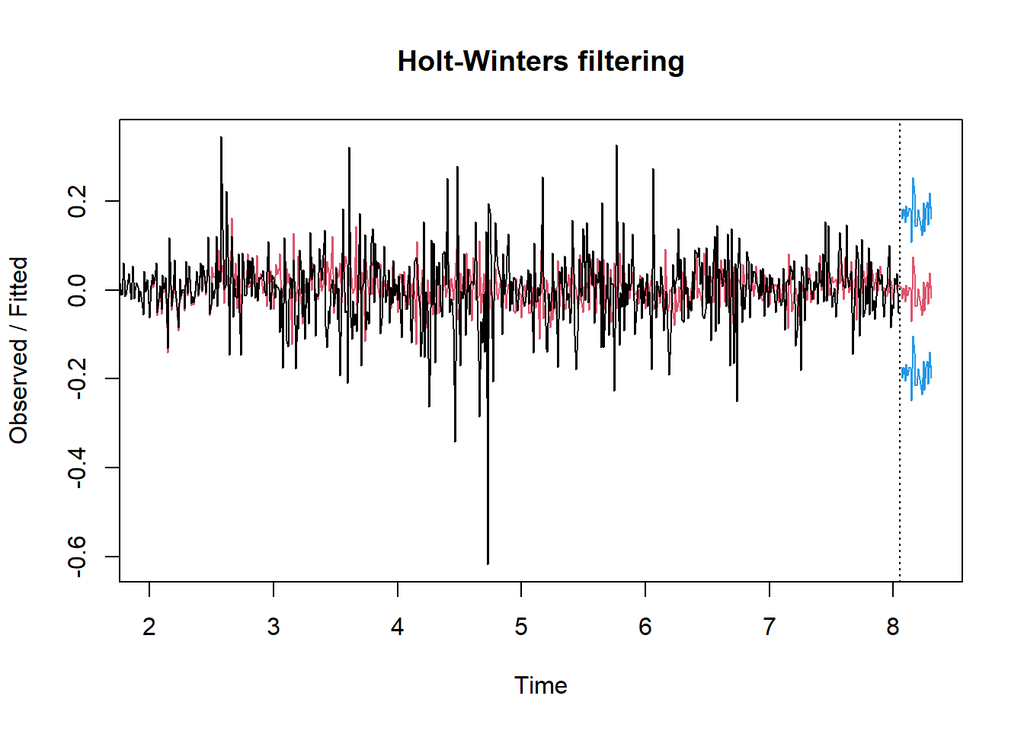

```r
forecast.hw <- predict(hw.fit, n.ahead = 24, prediction.interval = T, level = 0.95)
plot(hw.fit, forecast.hw)
```